# Example-Report - Angola

2025-05-29

# Trend of Incidence of HIV Infection in {Angola}, 1990 - 2009

## Table of Contents

- Introduction
- Methods
- Results
  - Trend of HIV Incidence
  - HIV Cases Summary Table
- Conclusion
- References

## Introduction

Human immunodeficiency virus (HIV) infection is a global pandemic infection including {Angola} [1]. Monitoring the magnitude or burden of the HIV pandemic is vital in the countries of the word for making evidence based public health or healthcare decision.This is possible through Undertaking epidemiological descriptive analysis, using epidemic curve (line plot of number of cases of an epidemic disease over time) and disease frequency or incidence summary table. Such analysis and data visualizations help to assess the patterns of the HIV incidence over time [2], that indirectly indicates the impact of the HIV prevention and control programs globally and locally over time. Thus, the objective of this analysis was to analyze and visualize the trend of new HIV cases in {Angola} with R using the available HIV incidence data of the country.

## Methods

This analysis was carried out on data of {Angola} by filtering data of the relevant variables for the analysis from secondary dataset of HIV incidence of world countries made available for training in the Graph course website[2]. The analysis and data visualization were made after necessary data cleaning and manipulation had been conducted. The analysis undertaken is only descriptive analysis using R programming to show the trend and summary table of the incidence of HIV of the country over the specified years.

## Results

### Trend of HIV Incidence

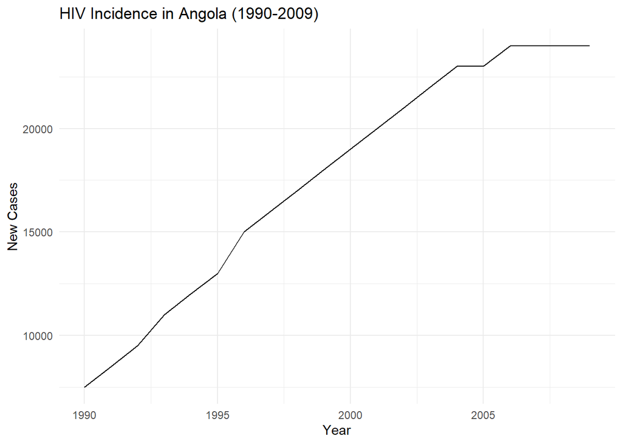

```r
hiv_incidence_data <- subset(hiv_data2, country == params$country)
ggplot(hiv_incidence_data, aes(x = year, y = new_cases)) +
  geom_line() +
  theme_minimal() +
  labs(title = paste("HIV Incidence in", params$country, "(1990-2009)"),
       x = "Year",
       y = "New Cases")
```

The line graph shows the number of new cases of HIV in {Angola} over the years included in the analysis.The line graph indicates cleanly the change in the number of people who were getting infected newly with HIV over time.

### HIV Cases Summary Table

```r
# Filter for selected country data
country_data <- hiv_data2 %>% filter(country == params$country)

# Summarize data by year
country_summary <- country_data %>%
    group_by(year) %>%
    summarise(Total_Cases = sum(new_cases))

# Identify the most recent year
most_recent_year <- max(country_summary$year)

# Display the table using kable and highlight the most recent year
country_summary %>%
    kable("html", caption = paste("Summary of HIV Cases in", params$country, "by Year")) %>%
    kable_styling(bootstrap_options = c("striped", "hover")) %>%
    row_spec(which(country_summary$year == most_recent_year), background = "lightblue")
```

Summary of HIV Cases in Angola by Year

| year | Total_Cases |
| --- | --- |
| 1990 | 7500 |
| 1991 | 8500 |
| 1992 | 9500 |
| 1993 | 11000 |
| 1994 | 12000 |
| 1995 | 13000 |
| 1996 | 15000 |
| 1997 | 16000 |
| 1998 | 17000 |
| 1999 | 18000 |
| 2000 | 19000 |
| 2001 | 20000 |
| 2002 | 21000 |
| 2003 | 22000 |
| 2004 | 23000 |
| 2005 | 23000 |
| 2006 | 24000 |
| 2007 | 24000 |
| 2008 | 24000 |
| 2009 | 24000 |

The table displays the incidence or new cases of HIV in {Angola} per each year. It also, highlights the most recent year’s data for easier identification.

## Conclusion

Both the table and the line plot offer invaluable information for public health or healthcare decision makers on the patterns of the HIV incidence over the specified years in the country. However, it is advisable to take in to account that the analysis undertaken was purly descriptive.

## References

[1]. WHO. HIV and AIDS: WHO fact sheet, 22 July 2024.Accessed on 02 May 2025: (https://www.who.int/news-room/fact-sheets/detail/hiv-aids)

[2].The Graph Course. EPIREP_EN_parameterizing_reports.Rmd, Accessed on April 30, 2025: (https://thegraphcourses.org/courses/epirep/topics/parametrizing-reports)